# Background

2024-12-27

## Abbreviations

- kACT = the kaolin based Activated Clotting Time (in seconds). This is the measured value of the ‘real’ (underlying ACT) with a device comparable to the one used in the study of Jain et al.
- ACT = the ‘real’ Activated Clotting Time.

## the Average Patient

We are doing our simulation based on ‘the average’ patient from the study from Jain et al. This means that we assume a patient with a weight of 93 kg with a measure baseline ACT (Activated Clotting Time) of 116 seconds. After receiving 33000 IU heparine the new measured ACT becomes 535 seconds. After Protamine administration the new measured ACT becomes 124.

```r
# data set

dat1 <- tibble(
  act_0= 116,
  hep=33000,
  act_33000 = 535,
  slope_hep= (act_33000-act_0)/33000,
  act_x = 124,
  hep_act_x = (act_x-act_0)/slope_hep
)
```

## Vizualisation

### Figure A: ACT changes after administration of Heparin.

P(kACT|Heparin), the relation (for the point-estimate) of the expected measured kACT based on the heparin dose, can be vizualized.

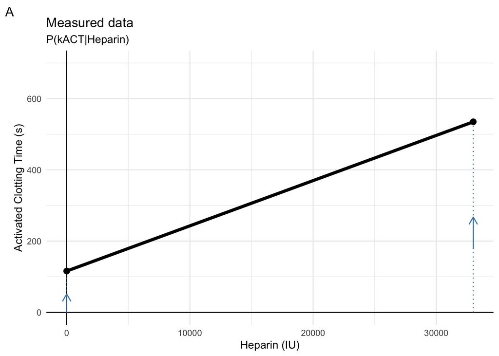

```r
# figA

fig_A <- ggplot(dat1)+
  geom_vline(xintercept = 0)+
  geom_hline(yintercept = 0)+
  geom_point(aes(x= 0, y= act_0),size=2.5)+
  geom_point(aes(x= 33000, y= act_33000),size=2.5)+

  # observed Heparin sensitivity
  geom_segment(aes(x= 0, xend=33000,
                   y= act_0, yend=act_33000), linewidth=1.5)+


  geom_segment(aes(x=0, xend=0, y=0, yend=113-10),
               col='steelblue',linewidth=0.5, linetype=3)+
  geom_segment(aes(x=0, xend=0, y=0, yend=(113-10)/2),
               arrow=arrow(length=unit(3, "mm")),
               col='steelblue',linewidth=0.5)+
  geom_segment(aes(x=33000, xend=33000,
                   y=0, yend=act_33000-10),
               col='steelblue',linewidth=0.5,linetype=3)+
  geom_segment(aes(x=33000, xend=33000,
                   y=act_33000/3, yend=act_33000/2),
               arrow=arrow(length=unit(3, "mm")),
               col='steelblue',linewidth=0.5,linetype=1)+

  theme_minimal()+

  labs(
    title='Measured data',
       subtitle='P(kACT|Heparin)',
    x='Heparin (IU)',
       y='Activated Clotting Time (s)',tag='A')+

  coord_cartesian(ylim=c(0,700))

fig_A
```

### Figure B: expected Heparin levels based on ACT measurement.

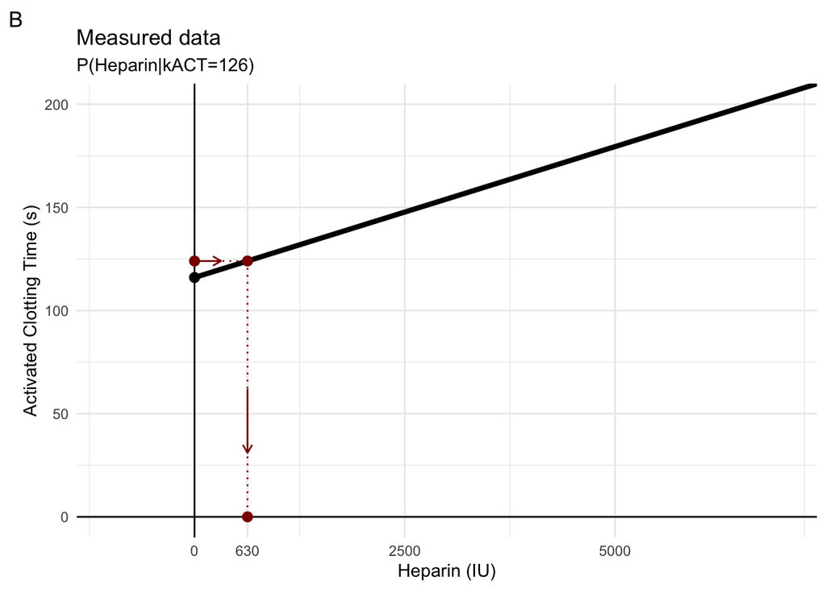

```r
fig_B <-ggplot(dat1)+
  geom_vline(xintercept = 0)+
  geom_hline(yintercept = 0)+
  geom_point(aes(x= 0, y= act_0),size=2.5)+
  geom_point(aes(x= 33000, y= act_33000),size=2.5)+

  # observed Heparin sensitivity
  geom_segment(aes(x= 0, xend=33000,
                   y= act_0, yend=act_33000), linewidth=1.5)+

  geom_segment(#data =dat1,
               aes(x= 0, xend = median(hep_act_x),
                   y= median(act_x), yend= median(act_x)),
               col='darkred', linetype=3,linewidth=0.5)+
  # pijltje in het midden
  geom_segment(#data =dat1,
    aes(x= 0, xend = 0.5*median(hep_act_x),
        y= median(act_x), yend= median(act_x)),
    col='darkred', linewidth=0.5,
    arrow=arrow(length=unit(2, "mm")))+

  geom_segment(
    aes(x= median(hep_act_x), xend = median(hep_act_x),
        yend= 0, y= median(act_x)),
    col='darkred', linetype=3,linewidth=0.5)+

  # pijltje in het midden
  geom_segment(
               aes(x= median(hep_act_x), xend = median(hep_act_x),
                   yend= 0.25*median(act_x), y= 0.5*median(act_x)),
               col='darkred', linewidth=0.5,
               arrow=arrow(length=unit(2, "mm")))+

  geom_point( aes(x= median(hep_act_x), y= median(act_x)),
              col='darkred', size=2.5)+


  geom_point(aes(x= median(hep_act_x), y= 0),
             col='darkred', size=2.5)+
  geom_point(aes(x= 0, y= median(act_x)),
             col='darkred', size=2.5)+

  theme_minimal()+
  labs(
    title='Measured data',
       subtitle='P(Heparin|kACT=126)',
    x='Heparin (IU)',
       y='Activated Clotting Time (s)',tag='B')+
  coord_cartesian(ylim=c(0,200), xlim=c(-1000,7000))+
  scale_x_continuous(minor_breaks = c(-1250,1250,3750,7250),
                     breaks = c(0,dat1$hep_act_x,2500,5000),
                     labels=c(0,round(dat1$hep_act_x,0),2500,5000))

fig_B
```